# Exotic Species, Introduction of - ScienceDirect

[figure not shown]

## Outline

1. Introduction
2. History
3. The Vectors of Exotic Species
4. The Increasing Emergence of Unexplained Events
5. Vulnerable Regions
6. Mode of Life
7. Impacts on Society
8. Management of Exotic Species
9. Biocontrol
10. Management
11. Conclusions
12. Further Reading
13. Relevant Websites

## Cited By (1)

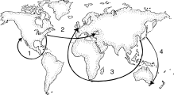

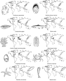

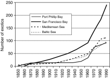

[Reference Module in Earth Systems and Environmental Sciences](https://www.sciencedirect.com/science/referenceworks/9780124095489)

## [Encyclopedia of Ocean Sciences (Third Edition)](https://www.sciencedirect.com/science/referenceworks/9780128130827)

[Volume 6](https://www.sciencedirect.com/science/referenceworks/9780124095489), 2009, Pages 289-300

# Exotic Species, Introduction of

[D.Minchin](https://www.sciencedirect.com/science/article/pii/B9780128130810007667#!)

## First page preview

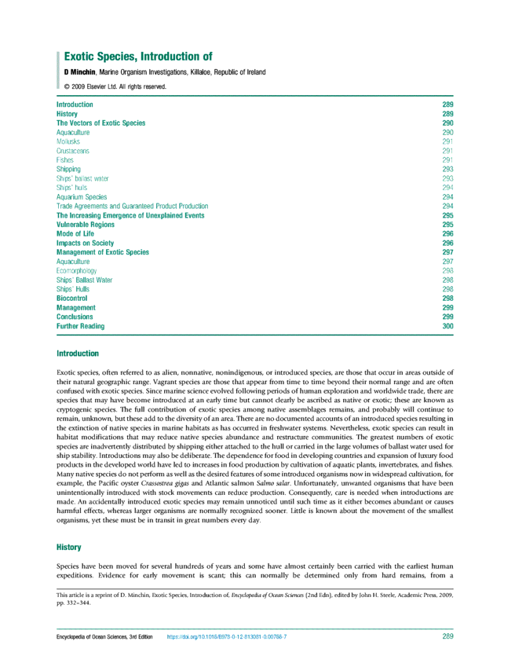

## Cited by (1)

### A new signal of tropicalization in the northeast atlantic: The spread of the spotfin burrfish chilomycterus reticulatus in madeira archipelago and its invasion risk

- 2021, Diversity

This article is a reprint of D. Minchin, Exotic Species, Introduction of, *Encyclopedia of Ocean Sciences* (2nd Edn), edited by John H. Steele, Academic Press, 2009, pp. 332–344.

Copyright © 2009 Elsevier Ltd. All rights reserved.

### Climate Change and Wild Species

- Encyclopedia of Biodiversity, 2013, pp. 79-99

### Fiord Circulation

- Encyclopedia of Ocean Sciences, Volume 6, 2019, pp. 74-81

### Air–Sea Gas Transfer: Nitrous Oxide and Methane

- Encyclopedia of Ocean Sciences, Volume 6, 2019, pp. 14-20